# Depressive symptoms in Brazilian medical students

Dataset 7: Resilience, learning environment and quality of life in Brazilian medical students

RSR feasibility analysis

2026-08-03

# Introduction

Tempski and colleagues surveyed a random sample of 1,350 students at 22 Brazilian medical schools in 2011-2012, measuring quality of life (WHOQOL-BREF), the perceived educational environment (DREEM), resilience, depressive symptoms and anxiety in a single cross-sectional questionnaire (Tempski et al., *PLOS ONE* 2015; doi:10.1371/journal.pone.0131535). Depression in medical students is consistently more common than in age-matched peers and is the outcome with the clearest link to attrition and to later physician burnout, so identifying which student and school characteristics travel with it is directly useful to curriculum committees and student support services.

**Aim.** Among Brazilian medical students, we examined which of sex, age, stage of the course, school legal status, resilience and the perceived educational environment are independently associated with the Beck Depression Inventory score, mutually adjusting for the others.

This is a *Purpose 3* analysis: several predictors are of interest and the question is which remain associated with the outcome after mutual adjustment.

# Methods

**Data source.** Multicentre cross-sectional survey of a random sample of 1,350 students drawn from 22 medical schools across Brazil, stratified by stage of the course (basic sciences, clinical sciences, clerkship). All variables used here are complete.

**Variables.** The outcome is `bdi_depression`, the Beck Depression Inventory total score, an integer from 0 to 63 (observed range 0 to 42) where higher means more depressive symptoms; a score of 14 or more conventionally indicates moderate or worse depression. Predictors are sex (reference: female, the larger group), age in years, stage of the course (reference: basic sciences, the earliest stage), school legal status (reference: public, the larger group and the traditional Brazilian medical school), the resilience scale score (16-98, higher = more resilient) and the DREEM global score (sum of the five DREEM subscales, higher = a more positive perceived educational environment). Continuous predictors are modelled per one-unit increase.

Deliberate exclusions. `dreem_global` is used **instead of** its five subscales, which sum to it exactly. Neither `state_anxiety` nor `trait_anxiety` is used as a predictor, even though both are strongly associated with the BDI (*r* = 0.59 and 0.73): all three are self-report scales of the same negative-affect construct, measured on the same day, and a model of depression on trait anxiety would be an instrument-validation exercise rather than a study of students. The four WHOQOL domains are excluded for the same reason - `whoqol_psychological` correlates -0.74 with the BDI. What is left is a model of depressive symptoms on demography, stage of training and the educational environment, which is the question a medical school would actually ask.

**Statistical analysis.** Linear regression (`lm()`), justified because the outcome is a continuous summed score with 38 distinct observed values. We fitted a univariable model for each predictor first, then a single multivariable model containing all of them. Predictors were chosen in advance on subject-matter grounds, not by significance. Significance threshold 0.05; estimates are reported with 95% confidence intervals. Assumptions were checked with `performance::check_model()`. Analysis used R version 4.6.0 (2026-04-24) with tidyverse, gtsummary and performance.

**Missing data.** Complete-case analysis: 1350 of 1350 rows were analysed (0 dropped).

# Results

## Sample characteristics

**Table 1. Sample characteristics.**

| **Characteristic** | **N** | **N = 1,350**<sup>1</sup> |
| --- | --- | --- |
| BDI total score (0-63) | 1,350 | 8 (4, 13) |
| Sex | 1,350 |  |
| Female |  | 714 (53%) |
| Male |  | 636 (47%) |
| Age (years) | 1,350 | 22.00 (21.00, 24.00) |
| Stage of course | 1,350 |  |
| Basic sciences |  | 459 (34%) |
| Clinical sciences |  | 491 (36%) |
| Clerkship |  | 400 (30%) |
| School legal status | 1,350 |  |
| Public |  | 882 (65%) |
| Private |  | 468 (35%) |
| Resilience score (16-98) | 1,350 | 81 (73, 88) |
| DREEM global score (0-200) | 1,350 | 120 (101, 139) |

<sup>1</sup> Median (Q1, Q3); n (%)

The median BDI score was 8 (IQR 4 to 13), and 314 students (23.3%) scored 14 or more, the conventional threshold for moderate or worse depression. The distribution is strongly right-skewed with a floor at 0, which matters for the diagnostics below.

## Exploratory figure

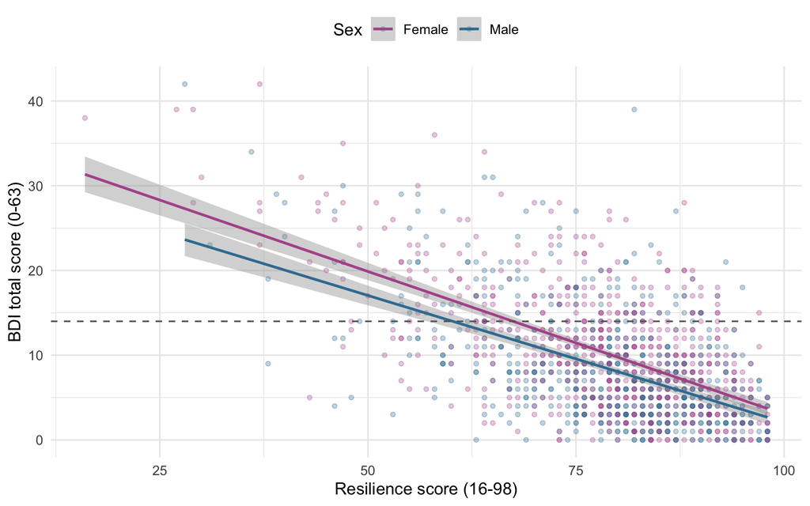

Figure 1. BDI score against resilience score, by sex. Points are individual students; lines are linear smoothers. The dashed line marks the moderate-depression threshold of 14.

## Univariable models

**Univariable linear regression.**

| **Characteristic** | **Beta** | **95% CI** | **p-value** |
| --- | --- | --- | --- |
| Sex |  |  |  |
| Female | — | — |  |
| Male | -2.1 | -2.8, -1.4 | <0.001 |
| Age (years) | -0.05 | -0.18, 0.07 | 0.4 |
| Stage of course |  |  |  |
| Basic sciences | — | — |  |
| Clinical sciences | -0.31 | -1.2, 0.59 | 0.5 |
| Clerkship | -0.54 | -1.5, 0.40 | 0.3 |
| School legal status |  |  |  |
| Public | — | — |  |
| Private | -0.41 | -1.2, 0.38 | 0.3 |
| Resilience score (16-98) | -0.32 | -0.35, -0.30 | <0.001 |
| DREEM global score (0-200) | -0.11 | -0.12, -0.09 | <0.001 |

Abbreviation: CI = Confidence Interval

## Why adjustment is needed

Two variables in this file plausibly confound the crude estimates. **The DREEM global score** confounds the school legal status contrast: private-school students rate their educational environment much more favourably (mean DREEM 128 versus 115 at public schools) and a better-rated environment goes with fewer depressive symptoms, so the null crude private-school coefficient is a mixture of two opposing forces and cannot be read at face value. **Stage of the course** confounds the crude age association, because the stages are ordered in time and clerkship students are on average four years older than basic-sciences students; an unadjusted age coefficient is really asking “do later-stage students differ”, not “do older students differ”. **Sex** is a third, though a weak one: women in this sample report slightly lower resilience scores (mean 78.1 versus 79.2) as well as clearly higher BDI scores, so a small part of the crude resilience association is a sex difference. Finally, **stage of the course** also confounds the DREEM association in the opposite direction - clerkship students rate their environment worst of the three stages (mean DREEM 114 versus 124) - so holding stage fixed is necessary before the DREEM coefficient can be interpreted. A single model with all six predictors makes each estimate conditional on the rest.

## Multivariable model

**Multivariable linear regression.**

| **Characteristic** | **Beta** | **95% CI** | **p-value** |
| --- | --- | --- | --- |
| Sex |  |  |  |
| Female | — | — |  |
| Male | -1.7 | -2.3, -1.1 | <0.001 |
| Age (years) | 0.08 | -0.04, 0.19 | 0.2 |
| Stage of course |  |  |  |
| Basic sciences | — | — |  |
| Clinical sciences | -0.36 | -1.1, 0.38 | 0.3 |
| Clerkship | -1.1 | -1.9, -0.19 | 0.017 |
| School legal status |  |  |  |
| Public | — | — |  |
| Private | 0.82 | 0.17, 1.5 | 0.013 |
| Resilience score (16-98) | -0.27 | -0.30, -0.24 | <0.001 |
| DREEM global score (0-200) | -0.05 | -0.07, -0.04 | <0.001 |

Abbreviation: CI = Confidence Interval

**Model fit**

| Statistic | Value |
| --- | --- |
| R-squared | 0.376 |
| Adjusted R-squared | 0.372 |
| Residual SE | 5.57 |
| n | 1350 |
| Model df | 7 |

The model explains 37.6% of the variance in BDI score (adjusted R-squared 0.372). Holding the other five predictors fixed, each resilience point is associated with -0.270 (95% CI -0.297 to -0.243) BDI points and each DREEM point with -0.054 (95% CI -0.067 to -0.041) BDI points, so a 20-point better perceived environment corresponds to about 1.1 fewer BDI points. Men score -1.65 (95% CI -2.25 to -1.06) points lower than women. Two coefficients that were null crudely become significant: clerkship students score -1.06 (95% CI -1.94 to -0.19) points lower than basic-sciences students (clinical sciences -0.36 (95% CI -1.10 to 0.38)), and private-school students score 0.82 (95% CI 0.17 to 1.46) points *higher* than public-school students. Age has no independent association (0.08 (95% CI -0.04 to 0.19)). All estimates are conditional associations from one cross-sectional survey and carry no causal claim.

## Unadjusted versus adjusted

**Table 2. Unadjusted and adjusted estimates.**

| **Characteristic** | **Unadjusted** **Beta** | **Unadjusted** **95% CI** | **Unadjusted** **p-value** | **Adjusted** **Beta** | **Adjusted** **95% CI** | **Adjusted** **p-value** |
| --- | --- | --- | --- | --- | --- | --- |
| Sex |  |  |  |  |  |  |
| Female | — | — |  | — | — |  |
| Male | -2.1 | -2.8, -1.4 | <0.001 | -1.7 | -2.3, -1.1 | <0.001 |
| Age (years) | -0.05 | -0.18, 0.07 | 0.4 | 0.08 | -0.04, 0.19 | 0.2 |
| Stage of course |  |  |  |  |  |  |
| Basic sciences | — | — |  | — | — |  |
| Clinical sciences | -0.31 | -1.2, 0.59 | 0.5 | -0.36 | -1.1, 0.38 | 0.3 |
| Clerkship | -0.54 | -1.5, 0.40 | 0.3 | -1.1 | -1.9, -0.19 | 0.017 |
| School legal status |  |  |  |  |  |  |
| Public | — | — |  | — | — |  |
| Private | -0.41 | -1.2, 0.38 | 0.3 | 0.82 | 0.17, 1.5 | 0.013 |
| Resilience score (16-98) | -0.32 | -0.35, -0.30 | <0.001 | -0.27 | -0.30, -0.24 | <0.001 |
| DREEM global score (0-200) | -0.11 | -0.12, -0.09 | <0.001 | -0.05 | -0.07, -0.04 | <0.001 |

Abbreviation: CI = Confidence Interval

The two headline predictors move only modestly toward the null. **Resilience** goes from -0.324 to -0.270, retaining 83% of its crude size - essentially nothing in this model explains it away. **Sex** retains 79% (-2.10 to -1.65), so the female excess in depressive symptoms is largely not accounted for by anything else in the model. **The DREEM global score** is the one that halves, from -0.107 to -0.054 (51% retained): much of the crude “bad environment goes with depression” association is really “low-resilience students both rate their school badly and score high on the BDI”.

Two coefficients change significance, both through suppression. **Private schooling** flips sign, from -0.41 crude and clearly non-significant (p = 0.30) to 0.82 adjusted and significant (p = 0.013). Private-school students rate their educational environment 13 DREEM points better on average, which pushes their crude BDI scores down; once DREEM is held fixed, a genuine private-school *excess* of depressive symptoms appears. **Clerkship** does the same: -0.54 crude (p = 0.26) becomes -1.06 (p = 0.017), because clerkship students rate their environment worst of the three stages and that was masking their lower depressive-symptom scores. **Age** barely moves in absolute terms (-0.053 to 0.078) and is non-significant throughout.

## Diagnostics

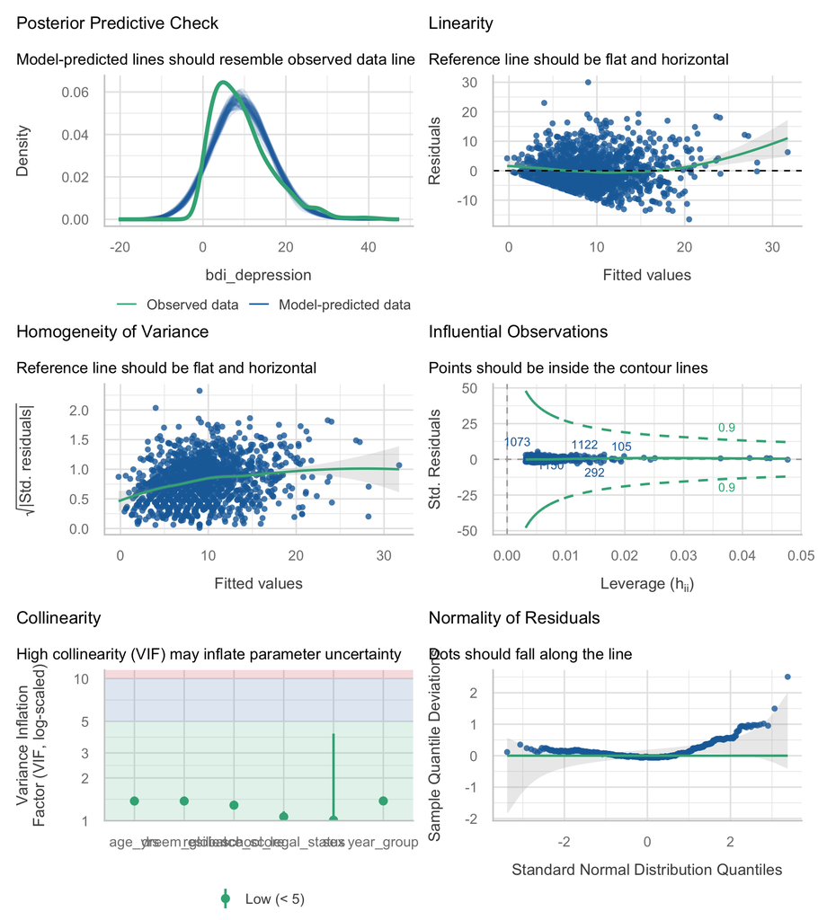

**Variance inflation factors**

| Term | VIF | Tolerance |
| --- | --- | --- |
| sex | 1.01 | 0.991 |
| age_yrs | 1.38 | 0.727 |
| year_group | 1.38 | 0.726 |
| school_legal_status | 1.07 | 0.938 |
| resilience_score | 1.29 | 0.777 |
| dreem_global | 1.38 | 0.727 |

**HC3 robust standard errors (sensitivity check)**

| term | estimate | robust SE | statistic | p.value |
| --- | --- | --- | --- | --- |
| (Intercept) | 36.284 | 1.689 | 21.48 | <0.001 |
| sexMale | -1.654 | 0.307 | -5.39 | <0.001 |
| age_yrs | 0.078 | 0.059 | 1.32 | 0.1869 |
| year_groupClinical sciences | -0.361 | 0.391 | -0.92 | 0.3559 |
| year_groupClerkship | -1.063 | 0.448 | -2.37 | 0.0179 |
| school_legal_statusPrivate | 0.819 | 0.319 | 2.57 | 0.0103 |
| resilience_score | -0.270 | 0.017 | -15.82 | <0.001 |
| dreem_global | -0.054 | 0.007 | -8.11 | <0.001 |

The robust standard errors are close to the model-based ones and every coefficient keeps its significance status, so the inference survives despite the clear heteroscedasticity.

**Influential points.** No observation exceeds the Cook’s distance threshold; the largest is 0.023, so despite the skew no single student drives the fit.

**Collinearity.** The highest VIF is 1.38 (age and stage of the course, which are strongly related by design), and every value is below 2. This is the direct result of excluding `state_anxiety` and `trait_anxiety`: had trait anxiety been added, it would have correlated 0.73 with the outcome and 0.61 with resilience, and the resilience coefficient would have been halved and its interpretation destroyed.

# Discussion

Depressive symptoms among Brazilian medical students are most strongly associated with low resilience, with women scoring about 1.7 BDI points higher than men, and with a poorly rated educational environment (about 1.1 BDI points per 20 DREEM points). Two findings emerge only after adjustment and are worth attention: clerkship students score lower than basic-sciences students once the educational environment is held fixed, and private-school students score higher than public-school students on the same basis. Practically, the DREEM association is the one a school can act on, but its size is modest - moving a school from the 25th to the 75th percentile of DREEM would be expected to shift the average BDI score by only a couple of points, well short of the 14-point clinical threshold.

**Limitations.** *Distributional mismatch.* The BDI is a bounded, right-skewed, integer score with a hard floor at 0 and 23% of students above the clinical threshold; a linear model gives interpretable coefficients but fits the shape of the outcome badly, produces impossible negative predictions at the low end, and shows marked heteroscedasticity. Dichotomising at 14 and fitting logistic regression, or modelling on the log scale, would respect the outcome’s shape better - at the cost of throwing away information or of interpretability. *Clustering is not modelled.* Students came from 22 medical schools, but the released file carries no school identifier, only `school_legal_status` and `school_location`; students in one school share teachers, curriculum and assessment load, so the reported standard errors - especially for the private-versus-public contrast, which is a school-level variable - are too narrow, and no random intercept can be fitted. *Cross-sectional design.* Resilience and depressive symptoms were measured at the same sitting, and a depressed student will answer a resilience questionnaire more negatively; the resilience association is therefore not evidence that resilience training would reduce depression. *No clinical assessment.* The BDI is a screening questionnaire, not a diagnosis, and self-report of mood on a survey administered by the medical school may be understated. *Unmeasured confounders* include family income, personal or family psychiatric history, and academic standing, none of which is in the file.

**Future work.** A cohort design measuring BDI at entry and at the end of each stage, with school identifiers retained, would separate selection into schools from the effect of the training environment.

# Feasibility notes

*Not part of a student report.*

- **Knits cleanly; no numerical trouble.** n = 1,350 complete cases, six predictors, max VIF 1.38, max Cook’s distance 0.023.
- **This outcome is a collinearity trap.** `trait_anxiety` correlates 0.73 with the BDI, `state_anxiety` 0.59, and `whoqol_psychological` -0.74. A student who drops all of those into the model gets R-squared above 0.6 and coefficients that are meaningless - they will have regressed one mood questionnaire on another. Excluding them is not optional; it is the whole design decision. If supervisors let students include `trait_anxiety` here, this outcome should be marked unusable.
- **Worst diagnostics of the six outcomes.** Skewness 1.16, a hard floor at 0, strongly rejected normality and the steepest scale-location slope in the dataset. HC3 rescues the inference, but a student who takes `check_model()` seriously will have a lot to write about, and honest prediction from this model is not possible.
- **Best suppression examples in the dataset.** Both `school_legal_status` and `year_group` flip from null to significant once `dreem_global` is held fixed, driven by the 13-point DREEM gap between private and public schools. This is a genuinely instructive unadjusted-versus-adjusted table.
- **The catalogue also offers this outcome as binary** (BDI >= 14, 23.3% of students, 314/1350 here). For a student who is uncomfortable defending a linear model on a skewed bounded score, the logistic version is the safer route and loses little.
- **Guardrails.** `dreem_global` must never appear with its five subscales; no WHOQOL domain and no anxiety scale as a predictor.
- **Verdict: workable but demanding.** Good effect sizes and a rich adjustment story, undermined by an outcome distribution that a linear model does not fit well and by an unusually tempting set of forbidden predictors.